# Project 1: Fully Connected Neural Networks

Instructions and assignment dates are available on [GitHub](https://birsakm.github.io/CS225-2025/).  
Your submission must be this notebook with all outputs saved inside.  
We will grade only what is visible in the notebook.

### Objectives

This assignment will help you practice:

- Basic Ibex
- Basic PyTorch
- Basic tensor operations
- Training a neural network

### Task

You will train a fully connected autoencoder on the Fashion-MNIST dataset.

### Autoencoder Goal

The goal of an autoencoder is to:

- Learn a compressed representation of input data (encoding).
- Reconstruct the original data from this representation (decoding).

The network is trained to minimize the difference between the input and the reconstructed output.  
Autoencoders are widely used for:

- Dimensionality reduction
- Denoising
- Anomaly detection

#### IBEX is the compute cluster we use in KAUST

- Policy for unassociated students: [link](https://docs.hpc.kaust.edu.sa/policy/ibex.html#limits-on-unassociated-users)  
  → Limit: 1 GPU (1080TI or 2080TI).
- Ibex Quickstart documentation: [link](https://docs.hpc.kaust.edu.sa/quickstart/ibex.html)
- Ibex 101 slides: [link](https://drive.google.com/file/d/13tiL3HjCu16cJ3GP_gR37xrvZ4h7W7KH/view)

**Note:** For this project you may request lower-end GPUs. These jobs typically start faster, and runtime will be similar.

### Submission

- We grade only the notebook content. All outputs must be visible.
- Submit a `.zip` file with the following format:  
  `P1_{LastName}_{FirstName}_V{version_number}.zip`

  Example: `P1_Smit_John_V1.zip`
- Include the notebook in the `.zip` file.
- You may also add a PDF version, but the `.ipynb` notebook is required.
- See announcements for further details.

```python
# Expected format of submission filess
FirstName = "Yeskendir" # Change me
LastName = "Zharkynbek" # Change me
version_number = 0
print(f"P1_{LastName}_{FirstName}.V{version_number}.zip")
print(f"P1_{LastName}_{FirstName}.V{version_number}.ipynb")
```

```
P1_Zharkynbek_Yeskendir.V0.zip
P1_Zharkynbek_Yeskendir.V0.ipynb
```

## TASK 1: Setup (10 points)

### Connecting to IBEX and SETUP

Concatenate the two tensors below along the **batch dimension** and print the result.

```python
a1 = torch.rand((3,256, 256))
b1 = torch.rand((2,3,256,256))
# TODO: Add/Modify your code below and print the shape
a1 = a1.unsqueeze(0)
r1 = torch.cat((a1, b1))
print(r1.shape)
```

```
torch.Size([3, 3, 256, 256])
```

### Task 2.2: Pytorch Gradient (2.5 points)

Use PyTorch’s built-in autograd to compute the gradient of  
y = 3x^3 + 2x + 1  
at x = 2.

```python
# TODO: Add/Modify your code below and print the shape
x = torch.tensor(2.0, requires_grad=True)
y = 3*(x**3) + 2*x + 1
y.backward()
print(x.grad)
```

```
tensor(38.)
```

### Task 2.3: Indexing (2.5 points)

Select every other element from the batch dimension, then reshape the last dimension into a square matrix.

```python
a1 = torch.rand((4,3,64 ** 2))
# TODO: Add/Modify your code below and print the shape
a_first = a1.shape[0]
a_second = a1.shape[1]
a_third = a1.shape[2]
print(a_first, a_second, a_third)
a_last = int(a_third**0.5)
print(a_last)
a1 = a1.reshape(a_first, a_second, a_last, a_last)
print(a1.shape)
```

```
4 3 4096
64
torch.Size([4, 3, 64, 64])
```

### Task 2.4: Fix the code (7.5 points)

Identify what is wrong with the code below.  
Correct the implementation and explain why it was incorrect.

**Hint:** Consider how the network is used inside an optimization loop for deep learning.

Can import extra classes if needed.

```python
class SimpleNetwork(nn.Module):
    def __init__(self):
        super(SimpleNetwork, self).__init__()
        self.layers = [
            nn.Linear(10, 20),
            nn.Linear(20, 5),
            nn.ReLU(),
        ]

    def forward(self, x):
        for layer in self.layers:
            x = layer(x)
        return x

class SimpleNetwork_correct(nn.Module):
    def __init__(self):
        super(SimpleNetwork, self).__init__()
        self.layers = nn.Sequential(
            nn.Linear(10, 20),
            nn.ReLU(),
            nn.Linear(20, 5),
        )

    def forward(self, x):
        x = self.layers(x)
        return x
```

Your interpretation and explanation:

- As i noticed, the first mistake is the order of layers. As we know form lectures, Linear layer then Linear layer gives us Linear layer. But the main idea of neural network or deep learning is going deep. So if Linear layer comes after linear layer, it is just combined 1 linear Layer. To have multiple layers and non-Linearity we need non-linear functions as ReLU or Sigmoid. Linear + Relu gives as non-Linear, and then adding another linear, would gives us multiple-layers. So overall, non linear functions as ReLU have to stay in between of Linear layers.
- Second one, i notised from tutorials [PyTorch Optimization Tutorial](https://docs.pytorch.org/tutorials/beginner/basics/optimization_tutorial.html) that self.layers not as matrix list, but as nn.Sequential. Then i started looking for difference, and found that Python list is not registrated in Module, but sequential is already submodule of Module. So when it goes to optimizer, it calls model parameters, so from sequential way it can be correctly seen, while python list is not registrated.
- Then in forward function, i found out that Sequential list has own forward pass, which goes from one layer to another. So there is no need for 'for loop'.

## TASK 3: Define data loaders (10 points)

Define **transforms, dataset, and dataloaders** for the [FashionMNIST](https://pytorch.org/vision/stable/datasets.html#fashion-mnist) dataset.

- Use train/val/test splits: **50k / 5k / 5k**
- Pad all images to **32 × 32**
- Use `torchvision.datasets.FashionMNIST` and `torch.utils.data.DataLoader`
- Explore `torch.utils.data` utilities to create the splits

The function `load_data()` must return a dictionary with training phases (`"train"`, `"val"`, `"test"`) as keys, and the corresponding dataloaders as values.

**Note:** Later in the report you will explain your choice of **batch size** and how it impacts training.

```python
# Follow the link above, and define the following variables
device = torch.device("cuda")
seed = 42
torch.manual_seed(seed)
np.random.seed(seed)
actual_datasets = {}
def load_data(batch_size, transform, data_dir= "mnist_data/"):
    full_dataset = torchvision.datasets.FashionMNIST(
        root=data_dir,
        train=True,
        download=True,
        transform=transform
    )
    train_size = 50000
    val_size = 5000
    test_size = 5000

    train_dataset, val_dataset, test_dataset = torch.utils.data.random_split(
        full_dataset,
        lengths=[train_size, val_size, test_size],
        generator=torch.Generator().manual_seed(42)
    )
    global actual_datasets
    actual_datasets = {
        "train": train_dataset,
        "val": val_dataset,
        "test": test_dataset
    }

    train_dataloader = torch.utils.data.DataLoader(train_dataset, batch_size=batch_size, shuffle=True)
    val_dataloader = torch.utils.data.DataLoader(val_dataset, batch_size=batch_size)
    test_dataloader = torch.utils.data.DataLoader(test_dataset, batch_size=batch_size)

    return {
        "train": train_dataloader,
        "val": val_dataloader,
        "test": test_dataloader
    }
batch_size = 64
transform = torchvision.transforms.Compose([
    transforms.Pad(2),
    transforms.ToTensor()
])

dataloaders = load_data(batch_size, transform)
dataset_sizes = {}
for i in actual_datasets.keys():
    print(i, " has a size: ", len(actual_datasets[i]), " in actual_datasets")
    dataset_sizes[i]  =  len(actual_datasets[i])

for i in dataloaders.keys():
    print(i, " has a size: ", len(dataloaders[i]), " in dataloader")

print("Dataset sizes: ", dataset_sizes)
```

```
train  has a size:  50000  in actual_datasets
val  has a size:  5000  in actual_datasets
test  has a size:  5000  in actual_datasets
train  has a size:  782  in dataloader
val  has a size:  79  in dataloader
test  has a size:  79  in dataloader
Dataset sizes:  {'train': 50000, 'val': 5000, 'test': 5000}
```

I used train set and devided to 3 parts

Train set has 60k, so first set for train 50k, 5k for validation and 5k for test

## Fully Connected Autoencoder

### TASK 4.1: Implement the autoencoder (12.5 points)

Implement a fully connected autoencoder with:

- **Four encoder layers**
- **Four decoder layers**
- Each layer uses a factor of **4 decrease (encoder)** or **4 increase (decoder)** in dimension

**Question:**

1. What would happen if we did not pad the images to 32×32?
2. What is the total compression ratio?

```python
dataiter = iter(dataloaders['train'])
images, labels = next(dataiter)
images = images.to(device)
labels = labels.to(device)
print(torch.min(images), torch.max(images))
```

```
tensor(0., device='cuda:0') tensor(1., device='cuda:0')
```

I used dataiter to see minimum and maximum value of image in first batch. So in next section, it would be helpful to use correct non-linear activation function in decoder. (learned from youtube tutorials)

```python
class MyNet(nn.Module):
    def __init__(self, initial_size=32*32):
        super(MyNet, self).__init__()
        self.encoder = nn.Sequential(
            nn.Linear(initial_size, int(initial_size/4)),
            nn.ReLU(),
            nn.Linear(int(initial_size/4), int(initial_size/16)),
            nn.ReLU(),
            nn.Linear(int(initial_size/16), int(initial_size/64)),
            nn.ReLU(),
            nn.Linear(int(initial_size/64), int(initial_size/256)),
            nn.ReLU()
        )
        self.decoder = nn.Sequential(
            nn.Linear(int(initial_size/256), int(initial_size/64)),
            nn.ReLU(),
            nn.Linear(int(initial_size/64), int(initial_size/16)),
            nn.ReLU(),
            nn.Linear(int(initial_size/16), int(initial_size/4)),
            nn.ReLU(),
            nn.Linear(int(initial_size/4), initial_size),
            nn.Sigmoid()
        )

    def forward(self, x):
        encoded = self.encoder(x)
        decoded = self.decoder(encoded)
        return decoded
```

**Q1**

If we used 28*28, it would be harder to make same layers(Symmetry) with factor of 4. 28*28->196->49->?->? it can not perfectly devided by 4. So for this task with this conditions "Each layer uses a factor of **4 decrease (encoder)** or **4 increase (decoder)** in dimension" is imposible to do it with 28*28

But with 32*32 is perfect factor of 4 1024->256->64->16->4

**Q2**

input size is 32*32=1024, latent size is 4, 1024->256->64->16->4, then total compression ratio 1024/4=256

#### TASK 4.1A Visualize an configuration (2.5 points)

Visualize a model summary (how many parameters, layers, etc.)  
Hint: Allowed to use libraries (e.g. torchsummary) for this or native PyTorch functions.

```python
pip install torchsummary
```

```
Downloading torchsummary-1.5.1-py3-none-any.whl (2.8 kB)
```

```python
from torchsummary import summary
model = MyNet()
model.to(device)
summary(model, input_size=(1024, ))
```

```
----------------------------------------------------------------
        Layer (type)               Output Shape         Param #
================================================================
            Linear-1                  [-1, 256]         262,400
              ReLU-2                  [-1, 256]               0
            Linear-3                   [-1, 64]          16,448
              ReLU-4                   [-1, 64]               0
            Linear-5                   [-1, 16]           1,040
              ReLU-6                   [-1, 16]               0
            Linear-7                    [-1, 4]              68
              ReLU-8                    [-1, 4]               0
            Linear-9                   [-1, 16]              80
             ReLU-10                   [-1, 16]               0
           Linear-11                   [-1, 64]           1,088
             ReLU-12                   [-1, 64]               0
           Linear-13                  [-1, 256]          16,640
             ReLU-14                  [-1, 256]               0
           Linear-15                 [-1, 1024]         263,168
          Sigmoid-16                 [-1, 1024]               0
================================================================
Total params: 560,932
Trainable params: 560,932
Non-trainable params: 0
----------------------------------------------------------------
Input size (MB): 0.00
Forward/backward pass size (MB): 0.03
Params size (MB): 2.14
Estimated Total Size (MB): 2.17
----------------------------------------------------------------
```

As we can see 1024->256->64->16->4 in encoder part and in Latent with shape 4, then goes to 4->16->64->256->1024 in decoder

The parameters were counted by input * output+output 64*16+16=1040

### TASK 4.2: Training and test code (5 points)

1. **Modify the code** to include validation during training.
2. **Extend the code** so it returns the loss for different stages of training for plotting purposes.

```python
def train_autoencoder(model, criterion, optimizer, dataloaders,
                       dataset_sizes, device, num_epochs=25,
                       save_path='saved_weight.pth', verbose=False):
    since = time.time()
    train_loss = []
    val_loss = []
    seed = 42
    torch.manual_seed(seed)
    np.random.seed(seed)
    for epoch in range(num_epochs):

        epoch_str = 'Epoch {}/{}'.format(epoch, num_epochs - 1)
        # Each epoch has a training phase
        for phase in ['train', 'val']:
            if phase == 'train':
                model.train()  # Set model to training mode
            else:
                model.eval()

            running_loss = 0.0

            # Iterate over data.
            for inputs, _ in dataloaders[phase]:  # Autoencoder doesn't need labels
                inputs = inputs.reshape(inputs.shape[0], -1)
                inputs = inputs.to(device)

                # zero the parameter gradients
                optimizer.zero_grad()

                # forward
                # track history if only in train
                with torch.set_grad_enabled(phase == 'train'):
                    outputs = model(inputs)

                    loss = criterion(outputs, inputs)  # Reconstruction loss

                    # backward + optimize only if in training phase
                    if phase == 'train':
                        loss.backward()
                        optimizer.step()

                # statistics
                running_loss += loss.item() * inputs.size(0)

            epoch_loss = running_loss / dataset_sizes[phase]
            if(phase == 'train'):
                train_loss.append(epoch_loss)
            else:
                val_loss.append(epoch_loss)
            if verbose:
                print('[{}] {} Loss: {:.4f}'.format(epoch_str, phase, epoch_loss))
    if verbose:
        print()
        time_elapsed = time.time() - since
        print('Training complete in {:.0f}m {:.0f}s'.format(time_elapsed // 60, time_elapsed % 60))

    torch.save(model.state_dict(), save_path)
    return model, train_loss, val_loss
```

```python
def test_autoencoder(model, dataloaders, dataset_sizes, device, criterion, load_path='saved_weight.pth'):
    # load the model weights
    model.load_state_dict(torch.load(load_path))

    since = time.time()

    for phase in ['test']:
        if phase == 'test':
            model.eval()   # Set model to evaluate mode

        running_loss = 0.0

        # Iterate over data.
        for inputs, _ in dataloaders[phase]:  # Autoencoder doesn't need labels
            inputs = inputs.reshape(inputs.shape[0], -1)

            inputs = inputs.to(device)

            with torch.no_grad():
                outputs = model(inputs)
                loss = criterion(outputs, inputs)  # Reconstruction loss

            # statistics
            running_loss += loss.item() * inputs.size(0)

        epoch_loss = running_loss / dataset_sizes[phase]

        print('{} Loss: {:.4f}'.format(phase, epoch_loss))

    time_elapsed = time.time() - since
    print('Testing complete in {:.0f}m {:.0f}s'.format(time_elapsed // 60, time_elapsed % 60))

    return epoch_loss
```

### Task 4.3: Combine code together (15 points)

- Run experiments with chosen setups to prepare data for **Task 4.4**.
- Implement a full deep learning pipeline, which might include:
  - Create model
  - Define optimizer
  - Select loss function
  - Train the model
  - Plot the losses

Note: Are we missing some steps?

**Requirements:**

- Explain design choices:
  - Which hyperparameters were selected and why
  - Which loss function was used
  - Any other architectural or training decisions

**Note:**

- `verbose=True` should only be used for debugging or testing.
- **Final submission must only include plots.**
- **Explanation can be combined with the plots below, not necessarily separate.**

*Hint:* Consider writing a helper function to run each experiment cleanly.

```python
# TODO: your code here
model = MyNet().to(device)
criterion = nn.MSELoss()
optimizer = optim.Adam(model.parameters(), lr=1e-3)
final_model, history_train_loss, history_val_loss = train_autoencoder(
    model,
    criterion,
    optimizer,
    dataloaders,
    dataset_sizes,
    device
)
```

Just checking the model

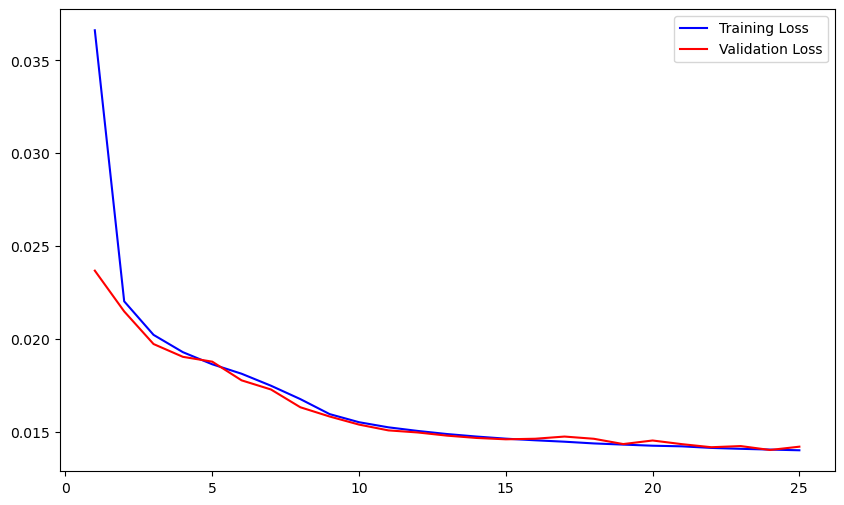

```python
import numpy as np

plt.figure(figsize=(10, 6))
epochs = np.arange(1, 26)

plt.plot(epochs, history_train_loss, label='Training Loss', color='blue')
plt.plot(epochs, history_val_loss, label='Validation Loss', color='red')
plt.legend()
plt.show()
```

pretty good training and validation

```python
def best_param(batch_size, num_epochs, learning_rate, criterion_name, optimizer_name):
    dataloaders = load_data(batch_size, transform)
    model = MyNet().to(device)

    if(optimizer_name == 'Adam'):
        optimizer = optim.Adam(model.parameters(), lr=learning_rate)
    elif(optimizer_name == 'SGD'):
        optimizer = optim.SGD(model.parameters(), lr=learning_rate, momentum=0.9)
    if(criterion_name == 'MSE'):
        criterion = nn.MSELoss()
    elif(criterion_name == 'MAE'):
        criterion = nn.L1Loss()

    final_model, history_train_loss, history_val_loss = train_autoencoder(
        model,
        criterion,
        optimizer,
        dataloaders,
        dataset_sizes,
        device,
        num_epochs
    )
    return np.min(history_val_loss), history_train_loss, history_val_loss
```

Here i compared v1, v2, v3, v4

For batch_size 32, 64, 128, 256

```python
v1, tl1, vl1 = best_param(32, 25, 1e-3, 'MSE', 'Adam')
print('v1: ', v1)
v2, tl2, vl2 = best_param(64, 25, 1e-3, 'MSE', 'Adam')
print('v2: ', v2)
v3, tl3, vl3 = best_param(128, 25, 1e-3, 'MSE', 'Adam')
print('v3: ', v3)
v4, tl4, vl4 = best_param(256, 25, 1e-3, 'MSE', 'Adam')
print('v4: ', v4)
```

```
v1:  0.01576262336373329
v2:  0.014278999076783656
v3:  0.014691276344656945
v4:  0.015268501572310925
```

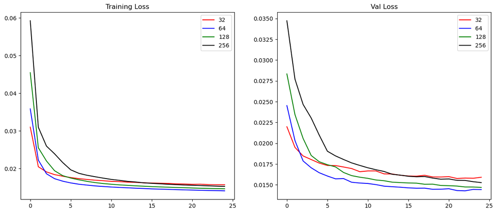

```python
fig, (ax1, ax2) = plt.subplots(1, 2, figsize=(15, 6))
ax1.plot(tl1, label='32', color='red')
ax1.plot(tl2, label='64', color='blue')
ax1.plot(tl3, label='128', color='green')
ax1.plot(tl4, label='256', color='black')
ax1.set_title('Training Loss')
ax1.legend()
ax2.plot(vl1, label='32', color='red')
ax2.plot(vl2, label='64', color='blue')
ax2.plot(vl3, label='128', color='green')
ax2.plot(vl4, label='256', color='black')
ax2.set_title('Val Loss')
ax2.legend()

plt.show()
```

Then determine which optimizer is better:

```python
v5, tl5, vl5  = best_param(64, 25, 1e-3, 'MSE', 'SGD')
print('v5: ', v5)
```

```
v5:  0.07377278230190278
```

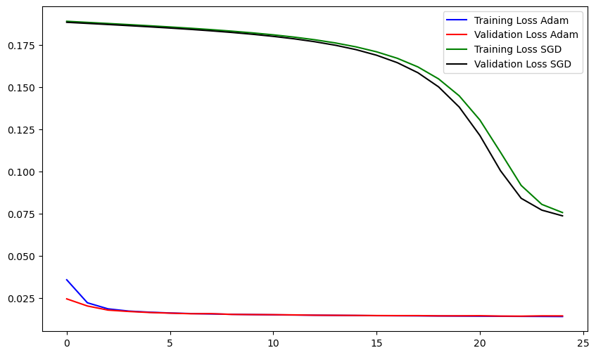

```python
plt.figure(figsize=(10, 6))
plt.plot(tl2, label='Training Loss Adam', color='blue')
plt.plot(vl2, label='Validation Loss Adam', color='red')
plt.plot(tl5, label='Training Loss SGD', color='green')
plt.plot(vl5, label='Validation Loss SGD', color='black')
plt.legend()
plt.show()
```

As a ressult, Adam optimizer is better than SGD for both train and validation sections

Here i will choose epoch number:

```python
v6, tl6, vl6 = best_param(64, 50, 1e-3, 'MSE', 'Adam')
print('v6: ', v6)
```

```
v6:  0.013722323188185693
```

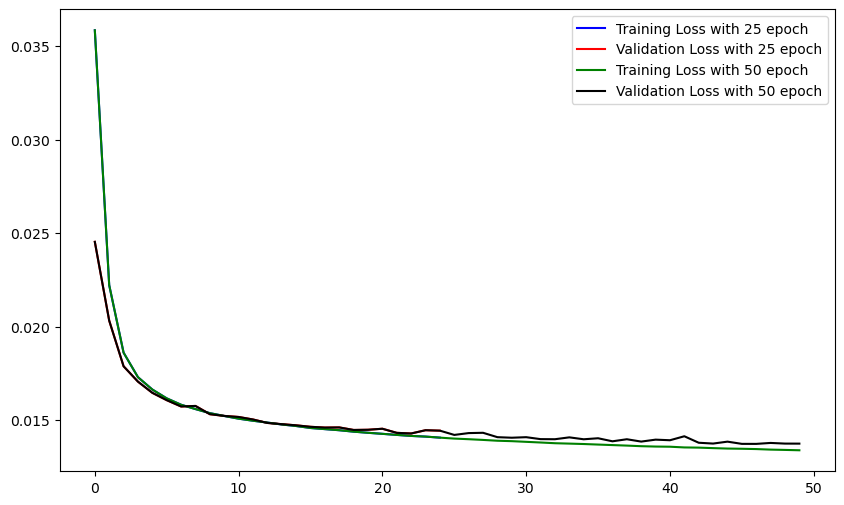

```python
plt.figure(figsize=(10, 6))
plt.plot(tl2, label='Training Loss with 25 epoch', color='blue')
plt.plot(vl2, label='Validation Loss with 25 epoch', color='red')
plt.plot(tl6, label='Training Loss with 50 epoch', color='green')
plt.plot(vl6, label='Validation Loss with 50 epoch', color='black')
plt.legend()
plt.show()
```

```python
print('Epoch 25, the loss: ', v2)
print('Epoch 50, the loss: ', v6)
```

```
Epoch 25, the loss:  0.014278999076783656
Epoch 50, the loss:  0.013722323188185693
```

As a result 50 epoch is better than 25, and it is good but i will continue with epoch 25 because it is faster and the difference is low.

I need to train fast(because of deadline)

```python
v7, tl7, vl7 = best_param(64, 25, 5e-3, 'MSE', 'Adam')
print('v7: ', v7)

v8, tl8, vl8 = best_param(64, 25, 1e-4, 'MSE', 'Adam')
print('v8: ', v8)

v9, tl9, vl9 = best_param(64, 25, 5e-4, 'MSE', 'Adam')
print('v9: ', v9)
```

```
v7:  0.01618834268450737
v8:  0.016559978145360945
v9:  0.014706366369128226
```

```python
v10, tl10, vl10,  = best_param(64, 25, 1e-5, 'MSE', 'Adam')

print('v10: ', v10)
```

```
v10:  0.029444385355710985
```

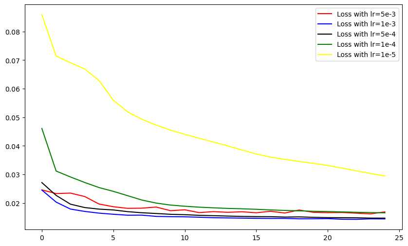

```python
plt.figure(figsize=(10, 6))
plt.plot(vl7, label='Loss with lr=5e-3', color='red')
plt.plot(vl2, label='Loss with lr=1e-3', color='blue')
plt.plot(vl9, label='Loss with lr=5e-4', color='black')
plt.plot(vl8, label='Loss with lr=1e-4', color='green')
plt.plot(vl10, label='Loss with lr=1e-5', color='yellow')
plt.legend()
plt.show()
```

learning rate is 0.001 is the best comparing with lr=1e-5 not enough epoch to decrease loss

So i will use lr=1e-3

### Task 4.4: Visualize Loss (5 points)

- Plot the **loss curves** for both training and validation sets.
- Add the **final test losses** as horizontal dashed lines for comparison.

**Notes (applies to Tasks 4.4 and 4.5):**

- Support your explanation with **multiple configurations** visualized.
- Show how different architectures or hyperparameters affect performance.
- You may either:
  - Combine multiple training runs into **one graph**, or
  - Provide **separate graphs** for each configuration.

```python
class MyNetexp(nn.Module):
    def __init__(self, initial_size=32*32, activ_f=nn.ReLU):
        super(MyNetexp, self).__init__()
        self.activ = activ_f()
        self.encoder = nn.Sequential(
            nn.Linear(initial_size, int(initial_size/4)),
            self.activ,
            nn.Linear(int(initial_size/4), int(initial_size/16)),
            self.activ,
            nn.Linear(int(initial_size/16), int(initial_size/64)),
            self.activ,
            nn.Linear(int(initial_size/64), int(initial_size/256)),
            self.activ
        )
        self.decoder = nn.Sequential(
            nn.Linear(int(initial_size/256), int(initial_size/64)),
            self.activ,
            nn.Linear(int(initial_size/64), int(initial_size/16)),
            self.activ,
            nn.Linear(int(initial_size/16), int(initial_size/4)),
            self.activ,
            nn.Linear(int(initial_size/4), initial_size),
            nn.Sigmoid()
        )

    def forward(self, x):
        encoded = self.encoder(x)
        decoded = self.decoder(encoded)
        return decoded
```

this class for experiment, i will change activation functions

```python
batch_size = 64
dataloaders = load_data(batch_size, transform)
criterion = nn.MSELoss()
num_epochs = 25
activation_func = [nn.ReLU, nn.LeakyReLU, nn.Tanh, nn.Sigmoid]
for f in activation_func:
    model = MyNetexp(activ_f = f).to(device)
    optimizer = optim.Adam(model.parameters(), lr=1e-3)
    exp_model, exp_history_train_loss, exp_history_val_loss = train_autoencoder(
        model,
        criterion,
        optimizer,
        dataloaders,
        dataset_sizes,
        device,
        num_epochs
    )
    print('For activation function ', str(f), 'The Loss: ', np.min(exp_history_val_loss))
```

```
For activation function  <class 'torch.nn.modules.activation.ReLU'> The Loss:  0.01419828420728445
For activation function  <class 'torch.nn.modules.activation.LeakyReLU'> The Loss:  0.013787292058765888
For activation function  <class 'torch.nn.modules.activation.Tanh'> The Loss:  0.01489281013160944
For activation function  <class 'torch.nn.modules.activation.Sigmoid'> The Loss:  0.02775620785355568
```

checking between 4 activatioin models

Lets choose the best activatioin function = LeakyReLU

```python
batch_size = 64
dataloaders = load_data(batch_size, transform)
model = MyNetexp(activ_f = nn.LeakyReLU).to(device)
optimizer = optim.Adam(model.parameters(), lr=1e-3)
criterion = nn.MSELoss()
num_epochs = 25

final_model, history_train_loss, history_val_loss = train_autoencoder(
    model,
    criterion,
    optimizer,
    dataloaders,
    dataset_sizes,
    device,
    num_epochs
)

test_loss = test_autoencoder(
    final_model,
    dataloaders,
    dataset_sizes,
    device,
    criterion = nn.MSELoss()
)
```

```
test Loss: 0.0140
Testing complete in 0m 1s
```

training my best model

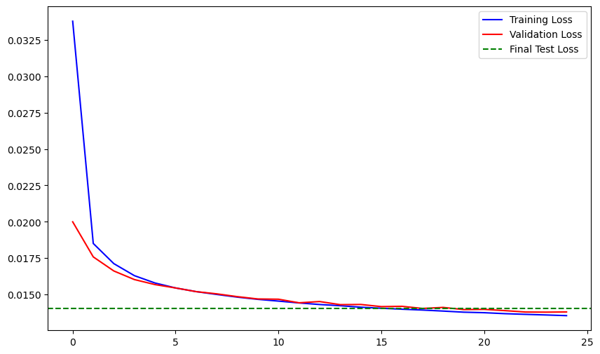

```python
from torchvision.utils import make_grid
from torchvision.transforms import ToPILImage
import matplotlib.pyplot as plt
plt.figure(figsize=(10, 6))
plt.plot(history_train_loss, label='Training Loss', color='blue')
plt.plot(history_val_loss, label='Validation Loss', color='red')
plt.axhline(y = test_loss, label='Final Test Loss', color='green', linestyle='--')
plt.legend()
plt.show()
# TODO: your code
```

as we can see it has not overfitting because training loss and val loss are close

Also test case slightly higher than val case

### Task 4.5: Visualize Reconstruction (10 points)

- Reconstruct the **first 10 test samples** using the trained autoencoder.
- Display results as a grid with **10 images per row** (inputs on one row, outputs on the next).
- You may use `torchvision.utils.make_grid` to create the visualization.

**Explanation:**

- Discuss the reconstruction results.
- Did the model behave as expected?

```python
# TODO: your code here
load_path='saved_weight.pth'
model = final_model
model.load_state_dict(torch.load(load_path, map_location=device))
model.eval()
inputs, _ = next(iter(dataloaders['test']))
inputs = inputs[:10].to(device)
inputs_flat = inputs.view(inputs.size(0), -1)

with torch.no_grad():
    outputs = model(inputs_flat)
outputs_reshaped = outputs.reshape(outputs.size(0), 1, 32, 32)

input_grid = make_grid(inputs.cpu(), nrow=10)
output_grid = make_grid(outputs_reshaped.cpu(), nrow=10)
plt.figure(figsize=(15, 6))
plt.subplot(2, 1, 1)
plt.imshow(np.transpose(input_grid.numpy(), (1, 2, 0)))
plt.subplot(2, 1, 2)
plt.imshow(np.transpose(output_grid.numpy(), (1, 2, 0)))
plt.show()
```

[output not shown]

### Task 4.6: Reconstruction with Noise (5 points) based on your best configuration of previous steps

- Add **salt-and-pepper noise** to the input images using the provided `add_salt_pepper_noise` function.
- Test reconstruction of the **same test samples** with noisy inputs.
- Vary the noise intensity.
- Show results for multiple levels of noise to demonstrate the effect.

**Explanation:**

- Compare reconstructions across different noise intensities.
- Discuss how noise affects different regions of the image (e.g., darker vs. brighter areas).

```python
def add_salt_pepper_noise(x, prob=0.01):
    noisy = x.clone()
    rand = torch.rand_like(x)
    noisy[rand < prob/2] = 0.0
    noisy[rand > 1 - prob/2] = 1.0
    return noisy
```

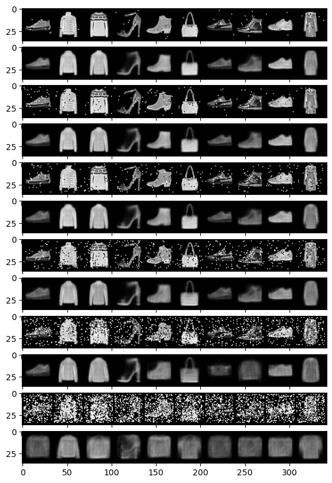

```python
load_path='saved_weight.pth'
model = final_model
model.load_state_dict(torch.load(load_path, map_location=device))

model.eval()

inputs, _ = next(iter(dataloaders['test']))
inputs = inputs[:10].to(device)

noise_levels = [0.01, 0.03, 0.05, 0.1, 0.2, 0.5]

plt.figure(figsize=(20, 10))

for i in range(len(noise_levels)):
    noisy_inputs = add_salt_pepper_noise(inputs, prob=noise_levels[i])
    noisy_inputs_flat = noisy_inputs.view(noisy_inputs.size(0), -1)

    with torch.no_grad():
        reconstructed_outputs = model(noisy_inputs_flat)
    outputs_reshaped = reconstructed_outputs.reshape(outputs.size(0), 1, 32, 32)



    input_grid = make_grid(noisy_inputs.cpu(), nrow=10)
    output_grid = make_grid(outputs_reshaped.cpu(), nrow=10)
    plt.subplot(len(noise_levels)*2, 1, 2*i+1)
    plt.imshow(np.transpose(input_grid.numpy(), (1, 2, 0)))
    plt.subplot(len(noise_levels)*2, 1, 2*i+2)
    plt.imshow(np.transpose(output_grid.numpy(), (1, 2, 0)))
plt.show()
```

pretty good results and based for noise_levels before 0.1 value is clear and recognaizable

with 0.5 it is just getting overall shape

### Task 4.7: Retrain Model with Noisy Inputs (10 points)

- Retrain the model using noisy input augmentations (same as in **Task 4.6**) under two conditions:
  1. Noise applied only to the **right half (50%) of the image**
  2. Noise applied to the **entire image**
- Rerun the training pipeline (**Task 4.3**) and visualizations (**Tasks 4.5 and 4.6**) for both settings.

**Explanation:**

- Compare the results of partial noise vs. full-image noise.
- Discuss how these two settings affect training and reconstruction.
- Explain how you would **validate your results** and support your observations.

**Note:**

- You may adapt existing methods with parametrization or reimplement them if needed.
- No additional dataloaders are required.

```python
# TODO: your code
def add_salt_pepper_noise_right(x, prob=0.01):
    noisy = x.clone()
    original_dim = noisy.dim()
    batch_size = noisy.shape[0]
    noisy = noisy.view(batch_size, 1, 32, 32)
    noisy[:, :, :, 16:] = add_salt_pepper_noise(noisy[:, :, :, 16:], prob)
    if original_dim == 2:
        return noisy.view(batch_size, -1)

    return noisy
```

```python
def train_autoencoder_with_noise(model, criterion, optimizer, dataloaders,
                       dataset_sizes, device, num_epochs=25, cond_noise = 'full' ,
                       save_path='saved_weight_noise.pth', verbose=False):
    since = time.time()
    train_loss = []
    val_loss = []
    for epoch in range(num_epochs):

        epoch_str = 'Epoch {}/{}'.format(epoch, num_epochs - 1)
        # Each epoch has a training phase
        for phase in ['train', 'val']:
            if phase == 'train':
                model.train()  # Set model to training mode
            else:
                model.eval()

            running_loss = 0.0

            # Iterate over data.
            for inputs, _ in dataloaders[phase]:  # Autoencoder doesn't need labels
                inputs = inputs.reshape(inputs.shape[0], -1)
                inputs = inputs.to(device)

                if(cond_noise == 'full'):
                    inputs_with_noise = add_salt_pepper_noise(inputs)
                elif(cond_noise == 'half'):
                    inputs_with_noise = add_salt_pepper_noise_right(inputs)
                else:
                    inputs_with_noise = inputs

                # zero the parameter gradients
                optimizer.zero_grad()

                # forward
                # track history if only in train
                with torch.set_grad_enabled(phase == 'train'):
                    outputs = model(inputs_with_noise)

                    loss = criterion(outputs, inputs)  # Reconstruction loss

                    # backward + optimize only if in training phase
                    if phase == 'train':
                        loss.backward()
                        optimizer.step()

                # statistics
                running_loss += loss.item() * inputs.size(0)

            epoch_loss = running_loss / dataset_sizes[phase]
            if(phase == 'train'):
                train_loss.append(epoch_loss)
            else:
                val_loss.append(epoch_loss)
            if verbose:
                print('[{}] {} Loss: {:.4f}'.format(epoch_str, phase, epoch_loss))
    if verbose:
        print()
        time_elapsed = time.time() - since
        print('Training complete in {:.0f}m {:.0f}s'.format(time_elapsed // 60, time_elapsed % 60))

    torch.save(model.state_dict(), save_path)
    return model, train_loss, val_loss
```

```python
batch_size = 64
dataloaders = load_data(batch_size, transform)
model = MyNetexp(activ_f = nn.LeakyReLU).to(device)
optimizer = optim.Adam(model.parameters(), lr=1e-3)
criterion = nn.MSELoss()
num_epochs = 25

final_model_noise_right, history_train_loss_noise_right, history_val_loss_noise_right = train_autoencoder_with_noise(
    model,
    criterion,
    optimizer,
    dataloaders,
    dataset_sizes,
    device,
    num_epochs,
    cond_noise = 'half'
)

test_loss_noise_right = test_autoencoder(
    final_model_noise_right,
    dataloaders,
    dataset_sizes,
    device,
    criterion = nn.MSELoss()
)
```

```
test Loss: 0.0140
Testing complete in 0m 1s
```

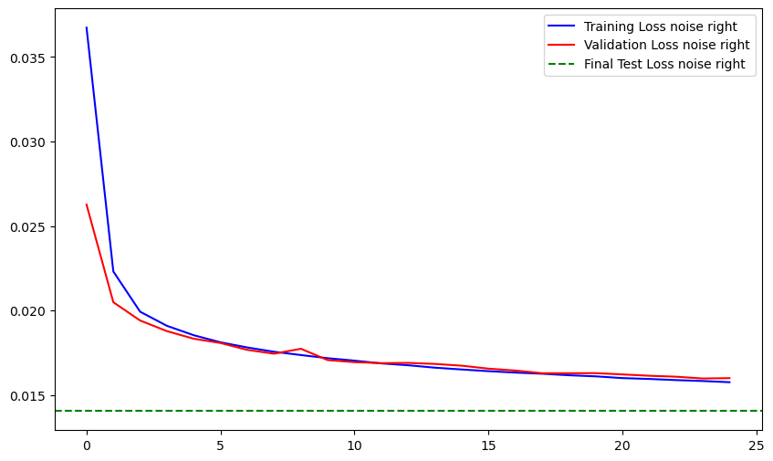

```python
from torchvision.utils import make_grid
from torchvision.transforms import ToPILImage
import matplotlib.pyplot as plt
plt.figure(figsize=(10, 6))
plt.plot(history_train_loss_noise_right, label='Training Loss noise right', color='blue')
plt.plot(history_val_loss_noise_right, label='Validation Loss noise right', color='red')
plt.axhline(y = test_loss_noise_right, label='Final Test Loss noise right', color='green', linestyle='--')
plt.legend()
plt.show()
```

With noise ofcorse model is getting not good as expected

```python
load_path='saved_weight.pth'
model = final_model_noise_right
model.load_state_dict(torch.load(load_path, map_location=device))
model.eval()
inputs, _ = next(iter(dataloaders['test']))
inputs = inputs[:10].to(device)
inputs_flat = inputs.view(inputs.size(0), -1)

with torch.no_grad():
    outputs = model(inputs_flat)
outputs_reshaped = outputs.reshape(outputs.size(0), 1, 32, 32)

input_grid = make_grid(inputs.cpu(), nrow=10)
output_grid = make_grid(outputs_reshaped.cpu(), nrow=10)
plt.figure(figsize=(15, 6))
plt.subplot(2, 1, 1)
plt.imshow(np.transpose(input_grid.numpy(), (1, 2, 0)))
plt.subplot(2, 1, 2)
plt.imshow(np.transpose(output_grid.numpy(), (1, 2, 0)))
plt.show()
```

[output not shown]

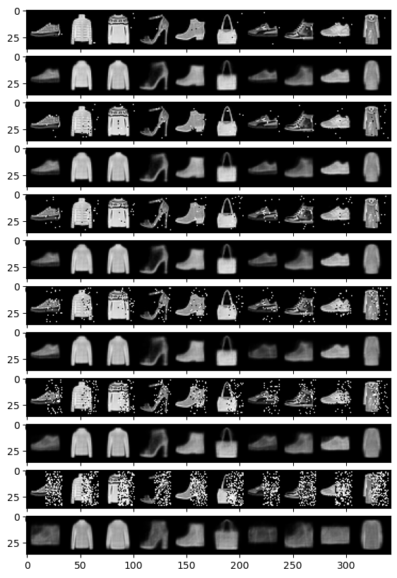

```python
load_path='saved_weight.pth'
model = final_model_noise_right
model.load_state_dict(torch.load(load_path, map_location=device))

model.eval()

inputs, _ = next(iter(dataloaders['test']))
inputs = inputs[:10].to(device)

noise_levels = [0.01, 0.03, 0.05, 0.1, 0.2, 0.5]

plt.figure(figsize=(20, 10))

for i in range(len(noise_levels)):
    noisy_inputs = add_salt_pepper_noise_right(inputs, prob=noise_levels[i])
    noisy_inputs_flat = noisy_inputs.view(noisy_inputs.size(0), -1)

    with torch.no_grad():
        reconstructed_outputs = model(noisy_inputs_flat)
    outputs_reshaped = reconstructed_outputs.reshape(outputs.size(0), 1, 32, 32)



    input_grid = make_grid(noisy_inputs.cpu(), nrow=10)
    output_grid = make_grid(outputs_reshaped.cpu(), nrow=10)
    plt.subplot(len(noise_levels)*2, 1, 2*i+1)
    plt.imshow(np.transpose(input_grid.numpy(), (1, 2, 0)))
    plt.subplot(len(noise_levels)*2, 1, 2*i+2)
    plt.imshow(np.transpose(output_grid.numpy(), (1, 2, 0)))
plt.show()
```

from right noise, the model has more clear views in left side.

```python
batch_size = 64
dataloaders = load_data(batch_size, transform)
model = MyNetexp(activ_f = nn.LeakyReLU).to(device)
optimizer = optim.Adam(model.parameters(), lr=1e-3)
criterion = nn.MSELoss()
num_epochs = 25

final_model_noise, history_train_loss_noise, history_val_loss_noise = train_autoencoder_with_noise(
    model,
    criterion,
    optimizer,
    dataloaders,
    dataset_sizes,
    device,
    num_epochs
)

test_loss_noise = test_autoencoder(
    final_model,
    dataloaders,
    dataset_sizes,
    device,
    criterion = nn.MSELoss()
)
```

```
test Loss: 0.0140
Testing complete in 0m 1s
```

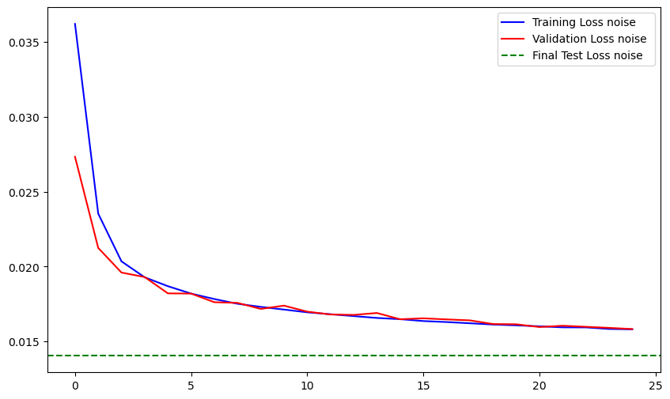

```python
from torchvision.utils import make_grid
from torchvision.transforms import ToPILImage
import matplotlib.pyplot as plt
plt.figure(figsize=(10, 6))
plt.plot(history_train_loss_noise, label='Training Loss noise ', color='blue')
plt.plot(history_val_loss_noise, label='Validation Loss noise ', color='red')
plt.axhline(y = test_loss_noise, label='Final Test Loss noise ', color='green', linestyle='--')
plt.legend()
plt.show()
```

Same for model with noise

```python
load_path='saved_weight.pth'
model = final_model_noise
model.load_state_dict(torch.load(load_path, map_location=device))
model.eval()
inputs, _ = next(iter(dataloaders['test']))
inputs = inputs[:10].to(device)
inputs_flat = inputs.view(inputs.size(0), -1)

with torch.no_grad():
    outputs = model(inputs_flat)
outputs_reshaped = outputs.reshape(outputs.size(0), 1, 32, 32)

input_grid = make_grid(inputs.cpu(), nrow=10)
output_grid = make_grid(outputs_reshaped.cpu(), nrow=10)
plt.figure(figsize=(15, 6))
plt.subplot(2, 1, 1)
plt.imshow(np.transpose(input_grid.numpy(), (1, 2, 0)))
plt.subplot(2, 1, 2)
plt.imshow(np.transpose(output_grid.numpy(), (1, 2, 0)))
plt.show()
```

[output not shown]

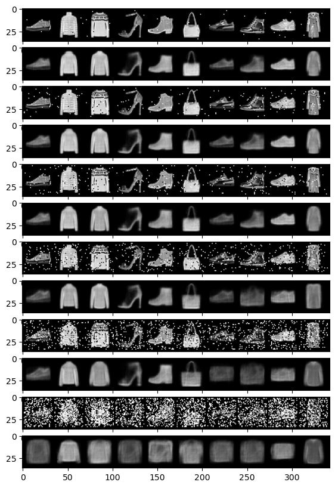

```python
load_path='saved_weight.pth'
model = final_model_noise
model.load_state_dict(torch.load(load_path, map_location=device))

model.eval()

inputs, _ = next(iter(dataloaders['test']))
inputs = inputs[:10].to(device)

noise_levels = [0.01, 0.03, 0.05, 0.1, 0.2, 0.5]

plt.figure(figsize=(20, 10))

for i in range(len(noise_levels)):
    noisy_inputs = add_salt_pepper_noise(inputs, prob=noise_levels[i])
    noisy_inputs_flat = noisy_inputs.view(noisy_inputs.size(0), -1)

    with torch.no_grad():
        reconstructed_outputs = model(noisy_inputs_flat)
    outputs_reshaped = reconstructed_outputs.reshape(outputs.size(0), 1, 32, 32)



    input_grid = make_grid(noisy_inputs.cpu(), nrow=10)
    output_grid = make_grid(outputs_reshaped.cpu(), nrow=10)
    plt.subplot(len(noise_levels)*2, 1, 2*i+1)
    plt.imshow(np.transpose(input_grid.numpy(), (1, 2, 0)))
    plt.subplot(len(noise_levels)*2, 1, 2*i+2)
    plt.imshow(np.transpose(output_grid.numpy(), (1, 2, 0)))
plt.show()
```

for low noise_level very good view